# Geographic data processing with R

2026-02-25

## Why R for geographic data processing?

- R is a powerful and flexible programming language for data analysis and visualization.
- R has a rich ecosystem of packages for working with geographic data (e.g. `sf` for vector data and `terra` for raster data)
- R allows for reproducible research and data processing workflows, making it easier to share and collaborate on projects.
- R has a large and active community of users and developers, providing support and resources for learning and troubleshooting.
- R allows for easier integration with downstream analyses (e.g. statistical modeling, machine learning, etc.) and visualization (e.g. `ggplot2`, etc.)

## What we will cover in this presentation

- Retrieval of geographic data from various sources (e.g. HydroSHEDS, HydroATLAS, HydroRIVERS)
- Processing of geographic data using R packages (e.g. `sf`, `terra`, `dplyr`, etc.)
- Basic spatial operations (e.g. spatial joins, buffering, etc.)
- Visualization of geographic data using R packages (e.g. `ggplot2`, etc.)

## Which packages we will use

- `sf` for vector data manipulation: sf represents spatial data in a simple, data.frame-like format
- `terra` for raster data manipulation: it’s the successor of the `raster` package and has a lot of useful functions for raster data
- `dplyr` for data manipulation: helps building pipelines for easy-to-read data manipulation (loaded with the `tidyverse`)
- `ggplot2` for data visualization: a bit painful, but easily integrates `sf` and `terra` objects for plotting (loaded with the `tidyverse`)
- `rnaturalearth` for retrieving natural earth data: provides easy access to natural earth vector data (e.g. country borders, etc.)
- `tidyterra` for integrating `terra` objects with the `tidyverse`

## Which packages we will use

```r
library(tidyverse)
library(sf)
library(terra)
library(rnaturalearth)
library(tidyterra)
library(viridis)
```

## The HydroSHEDS dataset

- [HydroSHEDS](https://www.hydrosheds.org/) (Hydrological data and maps based on SHuttle Elevation Derivatives at multiple Scales) is a global dataset of hydrological information derived from satellite data.
- It provides high-resolution data on river networks, watershed boundaries, and other hydrological features
- Data product [HydroRIVERS](https://www.hydrosheds.org/products/hydrorivers): river network data, including flow direction and flow accumulation
- Data product [HydroBASINS](https://www.hydrosheds.org/products/hydrobasins): outlines of river basins at multiple scales (from level 1 to level 12, with increasing detail)
- Data product [HydroATLAS](https://www.hydrosheds.org/hydroatlas): a collection of attributes for river basins, including physical, climatic, and anthropogenic characteristics

## HydroBASINS dataset

We start with [HydroBASINS](https://www.hydrosheds.org/products/hydrobasins) data.

- Different levels of details (1 to 12) with increasing resolution and number of basins
- The dataset can be downloaded as shapefile and has to be processed locally
- Here the data are already cropped for the Ebro river basin (Spain) at levels 5 and 10
- Let’s load in the environment the level 5 shapefile and check its content

## HydroBASINS dataset

```r
hydrosheds_lev5 <- "data/HydroBASINS_sample/sample__hybas_eu_lev05_v1c.shp" %>%
  sf::st_read() %>%
  sf::st_make_valid()
```

- The pipeline operator `%>%` concatenates functions
- `st_read()` reads the shapefile and creates an sf object
- `st_make_valid()` ensures that the geometries are valid (e.g. no self-loops)

## HydroBASINS dataset

We check the shapefile:

```r
class(hydrosheds_lev5)
```

```
## [1] "sf"         "data.frame"
```

- It is an object of class `sf`
- It is also an object of class `data.frame`: all data.frame functions work :)
- Is basically a data.frame with some other attributes and a geometry column

## HydroBASINS dataset

We check the shapefile content:

```r
head(hydrosheds_lev5)
```

```
## Simple feature collection with 1 feature and 13 fields
## Geometry type: POLYGON
## Dimension:     XY
## Bounding box:  xmin: -4.4 ymin: 40.34167 xmax: 2.154167 ymax: 43.17917
## Geodetic CRS:  WGS 84
##     HYBAS_ID NEXT_DOWN  NEXT_SINK   MAIN_BAS DIST_SINK DIST_MAIN SUB_AREA
## 1 2050017150         0 2050017150 2050017150         0         0  85458.8
##   UP_AREA PFAF_ID ENDO COAST ORDER SORT                       geometry
## 1 85458.8   21604    0     0     1  130 POLYGON ((-4.1759 43.04934,...
```

- Field HYBAS_ID is the unique identifier of each basin
- Use HYBAS_ID to filter full dataset to area of interest (in this case, HYBAS_ID == 2050017150, check e.g. with QGIS)

## HydroBASINS dataset

We plot the shapefile using `ggplot` and color-coding the attribute SUB_AREA:

```r
plot <- ggplot() +
  geom_sf(data = hydrosheds_lev5, aes(fill = SUB_AREA))
```

## HydroBASINS dataset

We plot the shapefile using `ggplot` and color-coding the attribute SUB_AREA:

```r
plot <- ggplot() +
  geom_sf(data = hydrosheds_lev5, aes(fill = SUB_AREA))
```

## HydroBASINS dataset

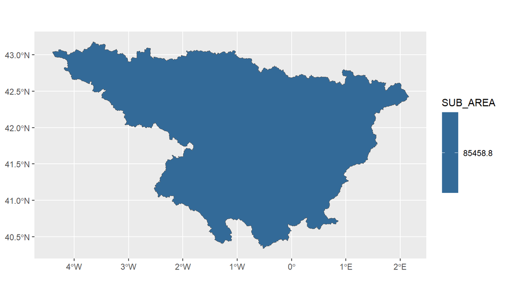

## HydroBASINS dataset

We try to make the plot a bit nicer. We use `ne_countries` to retrieve the world shapefile. We use `st_bbox()` to get the bounding box of the shapefile, then we use `st_crop()` to crop the world shapefile to the bounding box.

```r
crs_data <- hydrosheds_lev5 %>% sf::st_crs()

world <- rnaturalearth::ne_countries(scale="medium", returnclass="sf") %>%
  sf::st_transform(crs = crs_data ) %>%
  sf::st_as_sf(coords=c("Long", "Lat"), crs = crs_data )

bbox <- hydrosheds_lev5 %>%
  sf::st_bbox() %>%
  sf::st_as_sfc() %>%
  sf::st_buffer(1000 * 1000)

neighbors_cropped <- world %>%
  sf::st_crop(bbox) %>%
  dplyr::select(tlc, geometry)
```

```
Warning: attribute variables are assumed to be spatially constant throughout
all geometries
```

## HydroBASINS dataset

We try to make the plot a bit nicer. First we add the the background with the countries borders, then the HydroBASINS shapefile. Note that we set the limits of the plot manually.

```r
plot <- ggplot() +
  theme_bw() +
  geom_sf(data = neighbors_cropped,
          fill = "gray30",
          color = "gray80",
          alpha = 0.5, linewidth = 0.3) +
  geom_sf(data = hydrosheds_lev5, aes(fill = SUB_AREA)) +
  xlim(-10, 10) +
  ylim(35, 50)
```

## HydroBASINS dataset

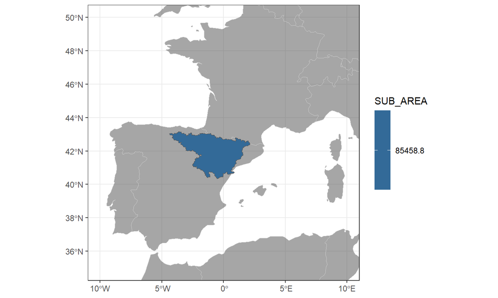

## HydroBASINS dataset level 10

Now we move forward and check the level 10, that has higher resolution.

```r
hydrosheds_lev10 <- "data/HydroBASINS_sample/sample__hybas_eu_lev10_v1c.shp" %>%
  sf::st_read() %>%
  sf::st_make_valid()
```

## HydroBASINS dataset level 10

We check the shapefile content:

```r
head(hydrosheds_lev10)
```

```
## Simple feature collection with 6 features and 13 fields
## Geometry type: MULTIPOLYGON
## Dimension:     XY
## Bounding box:  xmin: 0.3125 ymin: 40.59965 xmax: 0.8586015 ymax: 40.91728
## Geodetic CRS:  WGS 84
##     HYBAS_ID  NEXT_DOWN  NEXT_SINK   MAIN_BAS DIST_SINK DIST_MAIN SUB_AREA
## 1 2100017150          0 2100017150 2100017150       0.0       0.0    116.6
## 2 2101220850 2100017150 2100017150 2100017150      19.8      19.8    139.0
## 3 2100628730 2101220850 2100017150 2100017150      33.9      33.9    104.1
## 4 2100628500 2101220850 2100017150 2100017150      34.0      34.0     62.0
## 5 2101220040 2100628500 2100017150 2100017150      39.1      39.1    194.5
## 6 2101219600 2101220040 2100017150 2100017150      46.2      46.2    108.4
##   UP_AREA    PFAF_ID ENDO COAST ORDER  SORT                       geometry
## 1 84763.2 2160410101    0     0     1 23040 MULTIPOLYGON (((0.85 40.720...
## 2 84646.5 2160410102    0     0     1 23041 MULTIPOLYGON (((0.5342329 4...
## 3   300.2 2160410201    0     0     2 23042 MULTIPOLYGON (((0.4727517 4...
## 4 84207.1 2160410301    0     0     1 23043 MULTIPOLYGON (((0.4313772 4...
## 5 84145.1 2160410302    0     0     1 23044 MULTIPOLYGON (((0.5204756 4...
## 6 83950.8 2160410303    0     0     1 23045 MULTIPOLYGON (((0.3392422 4...
```

- Field HYBAS_ID is the unique identifier of each basin
- Use MAIN_BAS to filter full dataset to area of interest (in this case, MAIN_BAS == 2100017150, check with e.g. QGIS)

## HydroBASINS dataset level 10

We plot the shapefile using `ggplot` and color-coding the attribute SUB_AREA. We use scale_fill_viridis() to set the color palette

```r
plot <- ggplot() +
  theme_bw() +
  geom_sf(data = neighbors_cropped,
          fill = "gray30",
          color = "gray80",
          alpha = 0.5, linewidth = 0.3) +
  geom_sf(data = hydrosheds_lev10, aes(fill = SUB_AREA)) +
  scale_fill_viridis() +
  xlim(-5, 3) +
  ylim(40, 44)
```

## HydroBASINS dataset level 10

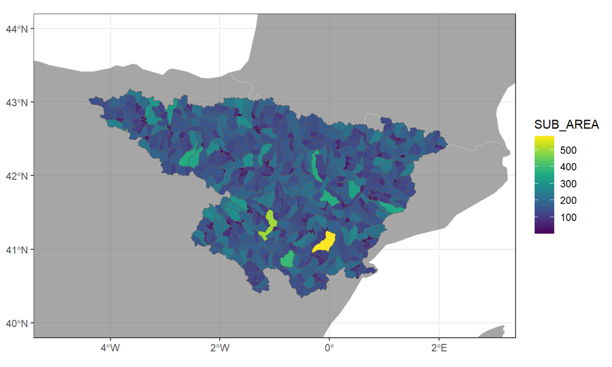

## Extracting data from raster sources

- HydroBASINS does not contain much information on the environmental conditions of the basins.
- We can add this information with some spatial operations.
- For now we focus on elevation and slope.
- We download the elevation data using the `elevatr` package, that retrieves elevation data from the [AWS Terrain Tiles dataset](https://registry.opendata.aws/terrain-tiles/).

```r
library(elevatr)

elevation <- hydrosheds_lev5 %>%
  elevatr::get_elev_raster(z = 8) %>%
  terra::rast()

names(elevation) <- "elevation"
```

## Extracting data from raster sources

The downloaded data are in a raster format and we can plot them directly.

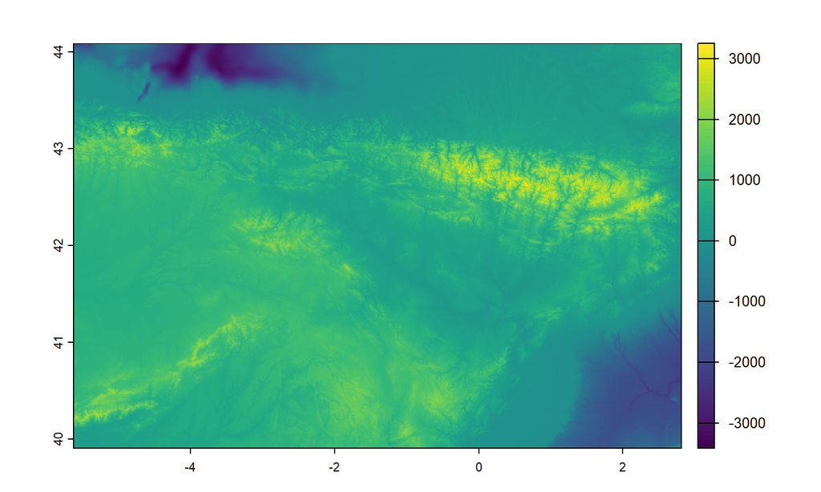

```r
plot(elevation)
```

## Extracting data from raster sources

We can also produce a plot with ggplot where we superimpose also other informations. Note that `geom_sf` does not have any aestetics, this is because we do not want things to change based on the attributes of the shapefile, but we just want to use it as a background.

```r
plot <- ggplot() +
  theme_bw() +
  tidyterra::geom_spatraster(data = elevation) +
  geom_sf(data = hydrosheds_lev5, fill = NA, color = "gray50", alpha = 0.5) +
  geom_sf(data = hydrosheds_lev10, fill = NA, color = "gray90", alpha = 0.5) +
  scale_fill_viridis(name = "Elevation (m)")
```

## Extracting data from raster sources

We can also produce a plot with ggplot where we superimpose also other informations.

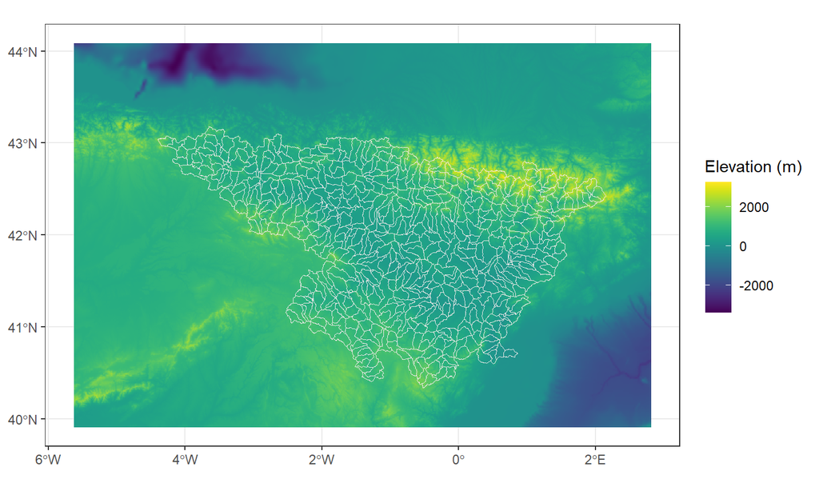

## Extracting data from raster sources

Based on the elevation data, we use the `terrain` function to calculate the slope and we plot it.

```r
slope <- elevation %>% terra::terrain(v = "slope", unit = "degrees")

names(slope) <- "slope"

plot <- ggplot() +
  theme_bw() +
  tidyterra::geom_spatraster(data = slope) +
  geom_sf(data = hydrosheds_lev5, fill = NA, color = "gray50", alpha = 0.5) +
  geom_sf(data = hydrosheds_lev10, fill = NA, color = "gray90", alpha = 0.5) +
  scale_fill_viridis(name = "Slope (degrees)")
```

## Extracting data from raster sources

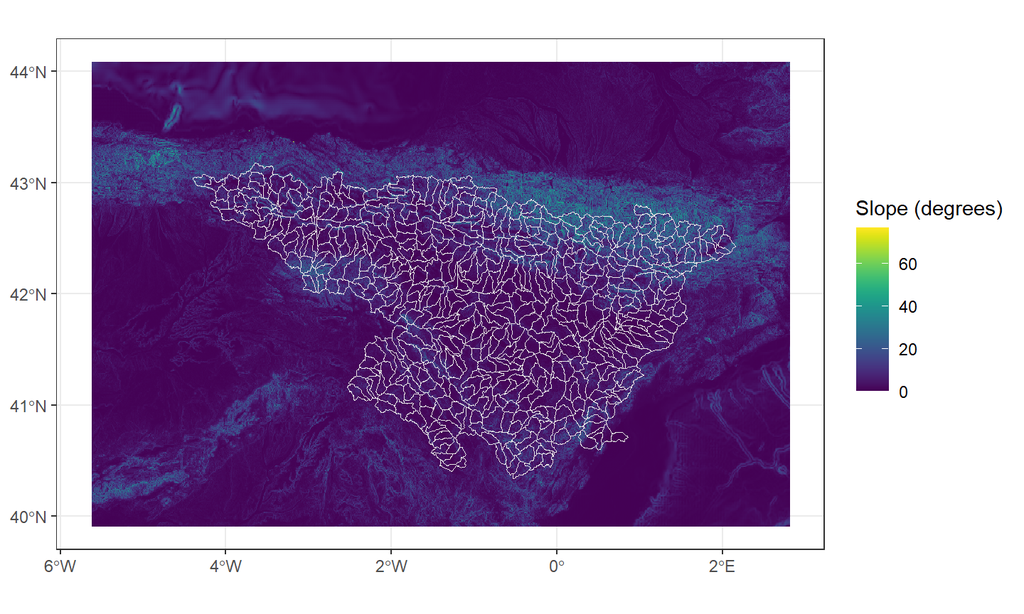

## Extracting data from raster sources

Now we would like to extract the information on the elevation and the slope and assign to each level 10 subcatchment the related information. We can do this with the `extract` function of the `terra` package, that extracts the values of a raster based on the geometries of a shapefile. Then, the information is added to the shapefile with a simple `mutate` function of `dplyr`. Note that we use the `fun = mean` argument to get the average elevation and slope of each subcatchment.

```r
elevation_extracted <- elevation %>%
  terra::extract(hydrosheds_lev10, fun = mean, na.rm = TRUE)

slope_extracted <- slope %>%
  terra::extract(hydrosheds_lev10, fun = mean, na.rm = TRUE)

hydrosheds_lev10 <- hydrosheds_lev10 %>%
  dplyr::mutate( elevation = elevation_extracted$elevation,
                 slope = slope_extracted$slope)
```

## Extracting data from raster sources

Now we can add elevation and slope to the plot.

```r
plot_elev <- ggplot() +
  theme_bw() +
  geom_sf(data = hydrosheds_lev5, fill = NA, color = "gray50", alpha = 0.5) +
  geom_sf(data = hydrosheds_lev10, aes(fill = elevation)) +
  scale_fill_viridis(name = "Elevation (m)")

plot_slope <- ggplot() +
  theme_bw() +
  geom_sf(data = hydrosheds_lev5, fill = NA, color = "gray50", alpha = 0.5) +
  geom_sf(data = hydrosheds_lev10, aes(fill = slope)) +
  scale_fill_viridis(name = "Slope (degrees)")
```

## Extracting data from raster sources

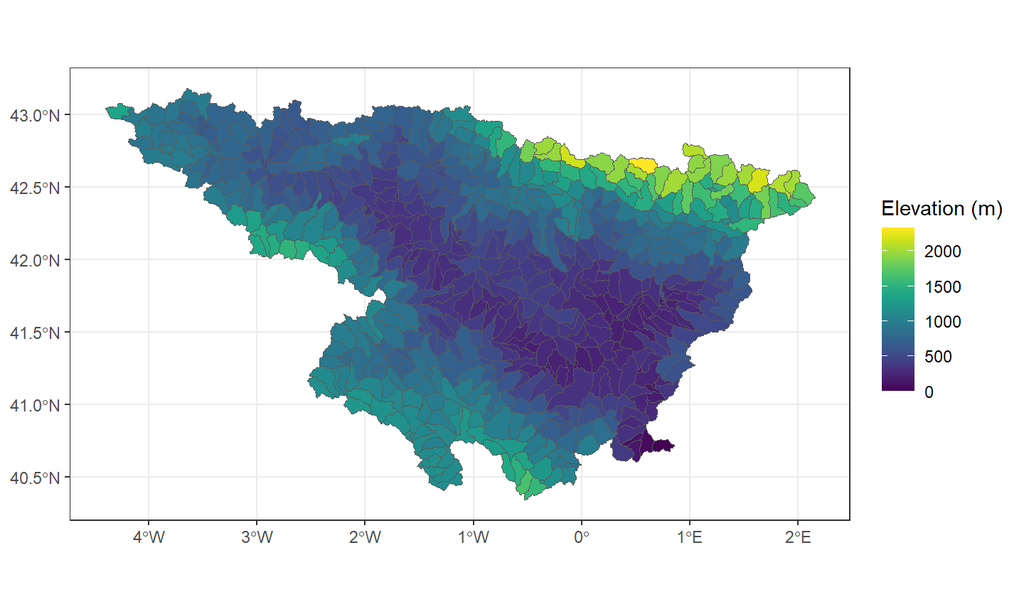

## Extracting data from raster sources

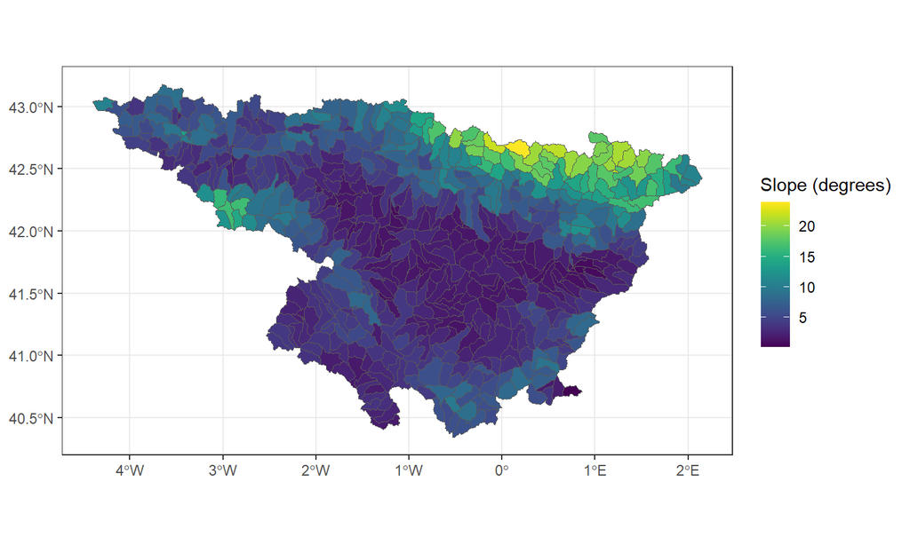

## HydroRIVERS dataset

No we focus on the [HydroRIVERS](https://www.hydrosheds.org/products/hydrorivers) dataset. The data are already cropped for the Ebro river basin (Spain). We see that the structure is similar to that of HydroSHEDS, except here the geometry type is LINESTRING instead of POLYGON.

```r
hydrorivers <- "data/HydroRIVERS_sample/sample__HydroRIVERS_v10_eu.shp" %>%
  sf::st_read() %>%
  sf::st_make_valid()
```

## HydroRIVERS dataset

Hydrorivers has several interesting attributes, such as the river order (ORD_STRA), the length of the river (LENGTH_KM), the average upland area (UPLAND_SKM), etc.

```r
head(hydrorivers)
```

```
## Simple feature collection with 6 features and 14 fields
## Geometry type: LINESTRING
## Dimension:     XY
## Bounding box:  xmin: -3.65 ymin: 43.11875 xmax: -3.45625 ymax: 43.15417
## Geodetic CRS:  WGS 84
##   HYRIV_ID NEXT_DOWN MAIN_RIV LENGTH_KM DIST_DN_KM DIST_UP_KM CATCH_SKM
## 1 20543793  20544331 20598415      0.69      752.2        3.9      8.77
## 2 20543882  20544331 20598415      2.21      752.2        4.6      7.36
## 3 20544331  20544539 20598415      2.65      749.7        7.1      4.54
## 4 20544539  20544633 20598415      1.82      747.9       10.8      4.70
## 5 20544540  20546914 20598415      4.49      743.4        7.2     12.69
## 6 20544541  20546914 20598415      1.73      743.4        4.5      6.89
##   UPLAND_SKM ENDORHEIC DIS_AV_CMS ORD_STRA ORD_CLAS ORD_FLOW  HYBAS_L12
## 1        8.8         0      0.219        1        5        7 2120587690
## 2        7.4         0      0.183        1        4        7 2120587690
## 3       20.7         0      0.518        2        4        7 2120587690
## 4       51.4         0      1.278        2        3        6 2120587690
## 5       12.7         0      0.297        1        4        7 2120587690
## 6        6.9         0      0.160        1        5        7 2120587690
##                         geometry
## 1 LINESTRING (-3.627083 43.15...
## 2 LINESTRING (-3.65 43.14167,...
## 3 LINESTRING (-3.627083 43.14...
## 4 LINESTRING (-3.614583 43.12...
## 5 LINESTRING (-3.504167 43.13...
## 6 LINESTRING (-3.45625 43.133...
```

## HydroRIVERS dataset

`ggplot` can be used to plot hydrorivers. Here we color-code the river segments based on the LENGTH_KM field, and transparency-code based on stream order (ORD_STRA).

```r
plot <- ggplot() +
  theme_bw() +
  geom_sf(data = hydrosheds_lev5, fill = "white", color = "gray50", alpha = 0.5) +
  geom_sf(data = hydrorivers, aes(color = LENGTH_KM, alpha = ORD_STRA)) +
  scale_color_viridis(name = "Length (km)") +
  scale_alpha_continuous(name = "Stream order")
```

## HydroRIVERS dataset

`ggplot` can be used to plot hydrorivers. Here, we color-code the river segments based on the LENGTH_KM field, and transparency-code based on stream order (ORD_STRA).

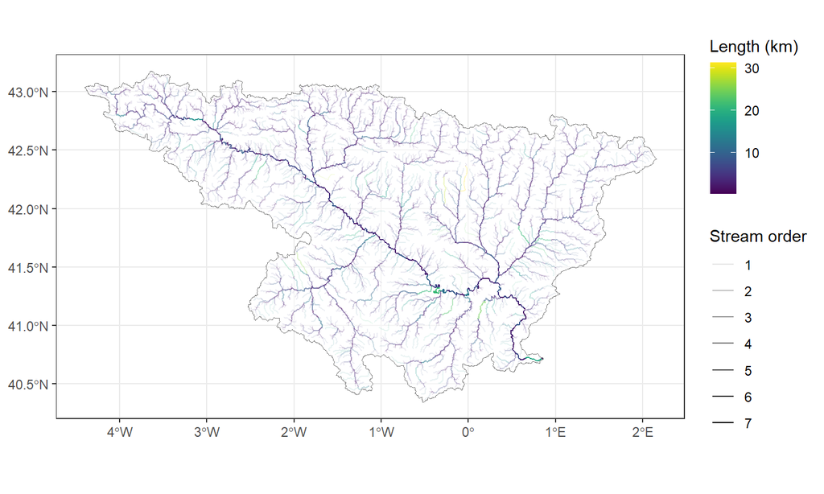

## HydroRIVERS dataset

The hydrorivers object is quite dense (~5000 river segments), so the plot is quite busy. In many cases, it might be useful to filter out low-order segments.

```r
nrow(hydrorivers)
```

```
## [1] 5021
```

```r
hydrorivers_filtered <- hydrorivers %>%
  dplyr::filter(ORD_STRA >= 3)

nrow(hydrorivers_filtered)
```

```
## [1] 1341
```

## HydroRIVERS dataset

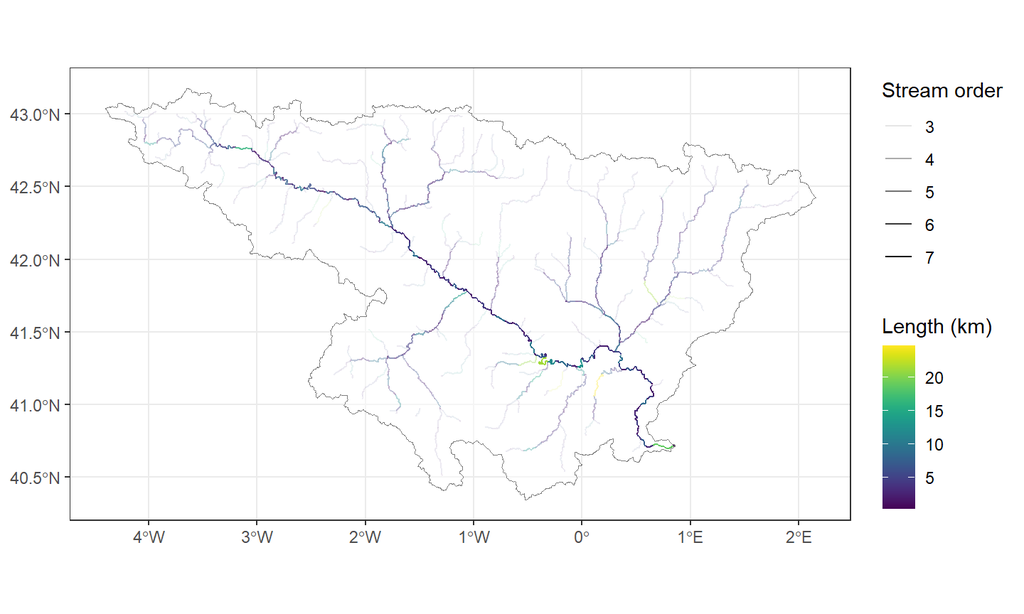

## HydroRIVERS dataset

The elevation and slope raster data can be extracted also for the river segments using the `extract` function as before.The function extracts the raster values underlying each segment and then calculates their mean value.

```r
elevation_extracted <- elevation %>%
  terra::extract(hydrorivers, fun = mean, na.rm = TRUE)

slope_extracted <- slope %>%
  terra::extract(hydrorivers, fun = mean, na.rm = TRUE)

hydrorivers <- hydrorivers %>%
  dplyr::mutate( elevation = elevation_extracted$elevation,
                 slope = slope_extracted$slope)
```

## HydroRIVERS dataset

The extracted values can be plotted. Not that now the scale_color_viridis is used to color-code the river segments based on the elevation and slope values.

```r
plot_elev <- ggplot() +
  theme_bw() +
  geom_sf(data = hydrosheds_lev5, fill = NA, color = "gray50", alpha = 0.5) +
  geom_sf(data = hydrorivers, aes(color = elevation)) +
  scale_color_viridis(name = "Elevation (m)")

plot_slope <- ggplot() +
  theme_bw() +
  geom_sf(data = hydrosheds_lev5, fill = NA, color = "gray50", alpha = 0.5) +
  geom_sf(data = hydrorivers, aes(color = slope)) +
  scale_color_viridis(name = "Slope (degrees)")
```

## HydroRIVERS dataset

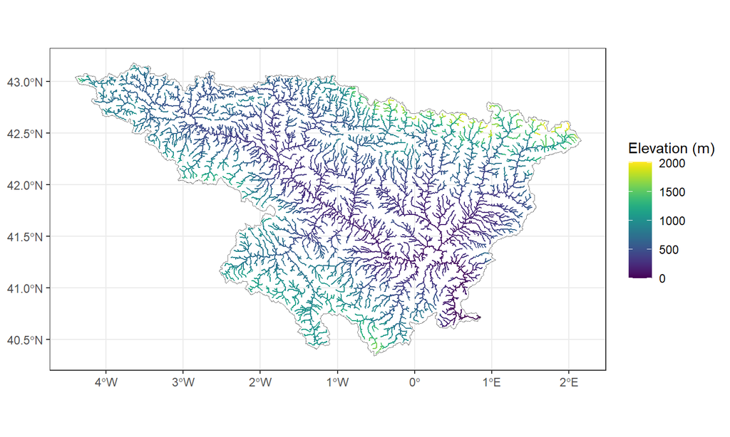

## HydroRIVERS dataset

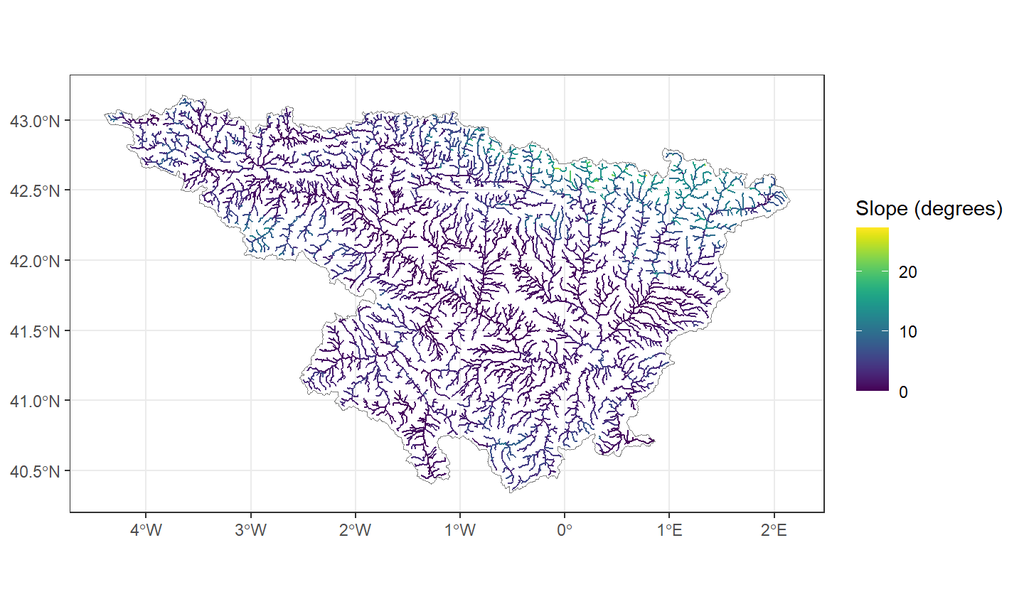

## HydroATLAS dataset

Finally, we load the [HydroATLAS](https://www.hydrosheds.org/hydroatlas) dataset, that contains a collection of attributes for river basins, including physical, climatic, and anthropogenic characteristics. The dataset contains both data aggregated at the subbasin level and data aggregated for river segments. The data are already cropped for the Ebro river basin.

To retain the data for the Ebro catchment:

- For BasinATLAS, the original data can be filtered based on the fields MAIN_BAS == 2100017150
- For RiverATLAS, the original data can be filtered based on the field MAIN_RIV == 20598415